# MPA : TP2

2024-10-20

## Question 1

On a, puisqu’il n’y a aucun élément émis à la fréquence $\theta_1$, et par indépendance des émissions :

$$\begin{align*}
p(y|c=1, \theta_1, \theta_2) & = \prod_{i=1}^n p(y_i|c=1, \theta_1,
\theta_2) \\& = \prod_{i=1}^n p(y_i|c=1, \theta_2) \\ & =
\prod_{i=1}^n \theta_2^{y_i} (1 - \theta_2)^{1-y_i}
\end{align*}$$

## Question 2

On a de manière plus générale :

$$\begin{align*}
p(y|c>1, \theta_1, \theta_2) & = \prod_{i=1}^{c-1} \theta_1^{y_i}
(1 - \theta_1)^{1-y_i} \prod_{i = c}^n \theta_2^{y_i} (1 -
\theta_2)^{1-y_i}
\end{align*}$$

## Question 3

$$p(\theta) = p(\theta_1, \theta_2, c) = \frac{1}{n}$$

$$p(\theta_1)= \int_{\theta_2 = 0}^{1} \sum_{c=1}^n p(\theta) \,d\theta_2
= 1$$
Donc $\theta_1$ suit une loi uniforme sur [0, 1].

$$\text{Posons } R_c = \frac{p(c|y, \theta_1, \theta_2)}{p(c=1|y,
\theta_1, \theta_2)}$$

Appliquons la formule de Bayes deux fois pour commencer :

$$\begin{equation*}
\begin{split}
R_c & = \underbrace{\dfrac{\text{p}(y \vert c , \theta_1,
\theta_2)\text{p}(c \vert \theta_1, \theta_2)}{\text{p}(y \vert
\theta_1, \theta_2)}}_{=p(c|y, \theta_1,
\theta_2)} . \underbrace{\dfrac{\text{p}(y \vert \theta_1,
\theta_2)}{\text{p}(y \vert c = 1 , \theta_1, \theta_2)\text{p}(c = 1
\vert \theta_1, \theta_2)}}_{=\dfrac{1}{p(c=1|y, \theta_1, \theta_2)}}
\\
& = \dfrac{\text{p}(c \vert \theta_1, \theta_2)}{\text{p}(c = 1
\vert \theta_1, \theta_2)}.\dfrac{\displaystyle\prod_{i=1}^{c-1}
\theta_1^{y_i} (1 - \theta_1)^{1-y_i} \displaystyle\prod_{i = c}^n
\theta_2^{y_i} (1 - \theta_2)^{1-y_i}}{\displaystyle\prod_{i=1}^n
\theta_2^{y_i} (1 - \theta_2)^{1-y_i}} \\
& = \dfrac{\text{p}(c \vert \theta_1, \theta_2)}{\text{p}(c = 1
\vert \theta_1, \theta_2)} \displaystyle\prod_{i = 1}^{c-1}
\dfrac{\theta_1^{y_i} (1 - \theta_1)^{1-y_i}}{\theta_2^{y_i} (1 -
\theta_2)^{1-y_i}} \\
& = \displaystyle\prod_{i = 1}^{c-1} \dfrac{\theta_1^{y_i} (1 -
\theta_1)^{1-y_i}}{\theta_2^{y_i} (1 - \theta_2)^{1-y_i}}
\end{split}
\end{equation*}$$
Car On sait que $\theta_1,\theta_2$ et c sont indépendants, et car c suit une loi uniforme par rapport à $\theta_1$ et $\theta_2$. Donc, $\dfrac{\text{p}(c \vert \theta_1, \theta_2)}{\text{p}(c = 1 \vert \theta_1, \theta_2)} = 1$.

Ainsi, on se rend compte que pour un $c$ fixé, on effectue de l’ordre de $c-1$ multiplications. La valeur de $c$ varie entre $1$ et $n$. Donc pour toutes les valeurs de $c$, on effectue (à un facteur près) $\displaystyle\sum_{c = 1}^{n} (c-1)$ multiplications, soit $\displaystyle\sum_{c = 0}^{n-1} c$ multiplications, ou plutôt de l’ordre de $\dfrac{n(n-1)}{2}$ multiplications..

## Question 4

On peut exhiber une relation de récurrence en fonction de $c$.

En effet on peut écrire pour $c \geq 2$ :

$$\begin{equation*}
\begin{split}
R_c & = \displaystyle\prod_{i = 1}^{c-1} \dfrac{\theta_1^{y_i} (1 -
\theta_1)^{1-y_i}}{\theta_2^{y_i} (1 - \theta_2)^{1-y_i}} \\
& = \dfrac{\theta_1^{y_{c-1}} (1 -
\theta_1)^{1-y_{c-1}}}{\theta_2^{y_{c-1}} (1 - \theta_2)^{1-y_{c-1}}}
\displaystyle\prod_{i = 1}^{c-2} \dfrac{\theta_1^{y_i} (1 -
\theta_1)^{1-y_i}}{\theta_2^{y_i} (1 - \theta_2)^{1-y_i}} \text{En
sortant le dernier terme du produit} \\
& = \dfrac{\theta_1^{y_{c-1}} (1 -
\theta_1)^{1-y_{c-1}}}{\theta_2^{y_{c-1}} (1 - \theta_2)^{1-y_{c-1}}}
R_{c-1}
\end{split}
\end{equation*}$$

Ainsi, on effectue $2$ multiplication pour passer d’un rapport à l’autre, ainsi puisqu’il y a $n$ rapports à calculer, on a un ordre de $n$ multiplications au TOTAL, en comptant en plus les nombre de petites multiplications à faire à chaque fois (la constante devant).

## Question 5

### Explication de l’algorithme

$\underline{\text{Donnée}}$ : un signal binaire $y$ qui contient deux parties : une partie avec des bits émis à la fréquence $\theta_1$ et l’autre partie avec des bits émis à la fréquence $\theta_2$, un nombre d’itérations $n_{iter}$.

$\underline{\text{Sortie}}$ : L’indice de changement détecté, la position estimée du point de changement, la borne inférieure de l’intervalle à 75%, la borne supérieure de l’intervalle à 75%, fréquence de “1” avant le point de changement, fréquence de “1” après le point de changement.

### Implémentation de l’algorithme

```r
gibbs <-function(y_vect, n_iter,theta1_th = -1, theta2_th = -1, changement_th = -1, theta1_init = -1, theta2_init = -1){
  n <- length(y_vect)
  # Créations des vecteurs pour stocker
  theta1_vect <- numeric(n_iter)
  theta2_vect<- numeric(n_iter)
  c_vect <- numeric(n_iter)

  # Valeurs initiales
  # Si une valeur initiale est donnée, on change sinon on prend par défaut thêta 1 et thêta 2 égaux à 1/2
  if (theta1_init == -1){
    theta1 <- 0.5
  }
  else {
    theta1 <- theta1_init
  }
  if (theta2_init == -1){
    theta2 <- 0.5
  }
  else {
    theta2 <- theta2_init
  }

  for (i in 1:n_iter) {
    theta1_vect[i] <- theta1
    theta2_vect[i] <- theta2
    prob_c_sachant_y <- numeric(n)
    # Initialisation de la récurrence
    prob_c_sachant_y[1] <- 1
    # On calcule grâce à l'algorithme de la question précédente toutes les valeurs des rapports R_c
    for (j in 2:n) {
      prob_c_sachant_y[j] <- prob_c_sachant_y[j-1] * ((theta1^y_vect[j-1] * (1 - theta1)^(1 - y_vect[j-1])) /
                                    (theta2^y_vect[j-1] * (1 - theta2)^(1 - y_vect[j-1])))
    }
    # Normalisation
    prob_c_sachant_y <- prob_c_sachant_y / sum(prob_c_sachant_y)
    # Echantillonnage de c
    c <- sample(1:n,1, prob = prob_c_sachant_y)

    # Mise à jour de theta1
    theta1 <- rbeta(1,sum(y_vect[1:c-1])+1,c-sum(y_vect[1:c-1]))

    # Mise à jour de theta2
    # Pour éviter la division par 0
    while (theta2 == 0 || theta2 == 1){
        theta2 <- rbeta(1,sum(y_vect[c:n])+1,n-c+2-sum(y_vect[c:n]))
    }
    c_vect[i]<- c
  }
  hist_p_c_sachant_y <-   hist_p_c_sachant_y <- hist(c_vect, freq = FALSE,breaks=n, main = paste("Histogramme réprésentant la loi de c sachant y,",n_iter," itérations"), xlab = "c", ylab = "Allure de p(c|y) à constante près")


  # Obtention des bornes de l'intervalle de confiance à 75%
  borne_inf <- quantile(c_vect, probs = 0.25/2)
  borne_sup <- quantile(c_vect, probs = 1 - 0.25/2)
  # Obtention du point de changement, en tant que point le plus présent dans l'intervalle de confiance
  intervalle <- c_vect[c_vect >= borne_inf & c_vect <= borne_sup]
  intervalle_occurence <- table(intervalle)
  c_changement <- as.numeric(names(intervalle_occurence)[which.max(intervalle_occurence)])
  # Calcul de la fréquence de 1 avant et après le changement
  frequence_avant <- sum(y_vect[1:c_changement-1]/(c_changement-1))
  frequence_apres <- sum(y_vect[c_changement:n]/(n-c_changement+1))

  # Affichage des données demandées
  valeur_tableau <- c(c_changement,borne_inf,borne_sup,frequence_avant,frequence_apres)
  nom_colonnes <- c("Point de changement","Borne inférieure de l'intervalle de confiance à 75%", "Borne supérieure de l'intervalle de confiance à 75%","Fréquence de 1 avant le changement","Fréquence de 1 après le changement")

  # Si l'on connaît les valeurs théoriques, les ajouter au tableau
  if (theta1_th != -1){
      valeur_tableau <- c(valeur_tableau,theta1_th)
      nom_colonnes <- c(nom_colonnes,"Thêta 1 théorique")
  }
  if (theta2_th != -1){
      valeur_tableau <- c(valeur_tableau,theta2_th)
      nom_colonnes <- c(nom_colonnes,"Thêta 2 théorique")
  }
  if (changement_th != -1){
      valeur_tableau <- c(valeur_tableau,changement_th)
      nom_colonnes <- c(nom_colonnes,"Point de changement théorique")
  }
  if (theta1_init != -1){
      valeur_tableau <- c(valeur_tableau,theta1_init)
      nom_colonnes <- c(nom_colonnes,"Thêta 1 initial pour l'algorithme")
  }
  if (theta2_init != -1){
      valeur_tableau <- c(valeur_tableau,theta2_init)
      nom_colonnes <- c(nom_colonnes,"Thêta 2 initial pour l'algorithme")
  }

  tableau <- data.frame(nom_colonnes,valeur_tableau)
  names(tableau) <- c("Donnée cherchée","Valeur")
  tableau

}
```

## Question 6

## Pour un cas assez évident

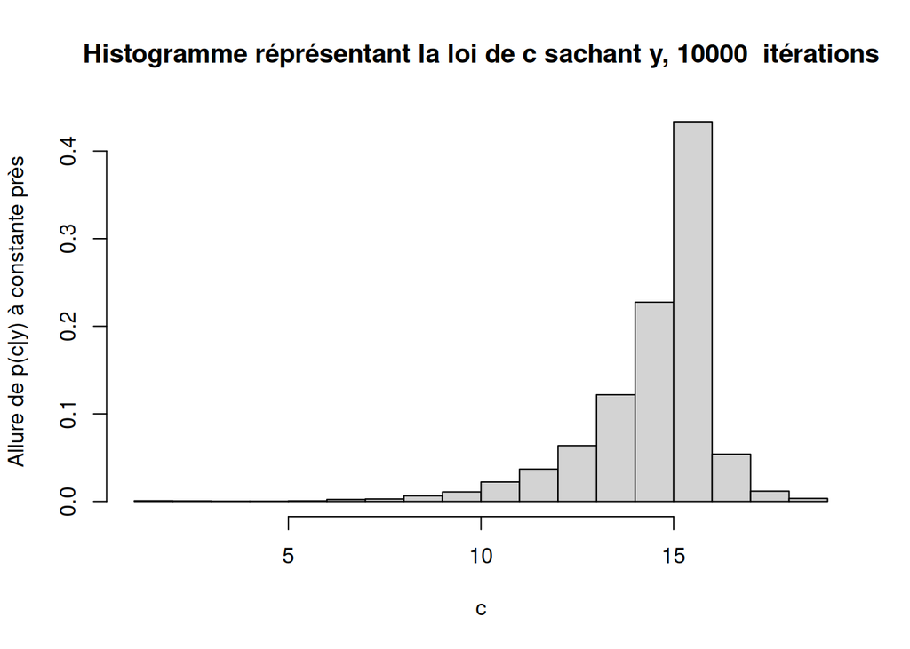

```
##                                       Donnée cherchée Valeur
## 1                                 Point de changement     16
## 2 Borne inférieure de l'intervalle de confiance à 75%     13
## 3 Borne supérieure de l'intervalle de confiance à 75%     16
## 4                  Fréquence de 1 avant le changement      1
## 5                  Fréquence de 1 après le changement      0
## 6                                   Thêta 1 théorique      1
## 7                                   Thêta 2 théorique      0
## 8                       Point de changement théorique     16
```

```r
y = c(1,1,1,1,1,1,1,1,1,1,1,1,1,1,1,0,0,0,0)
gibbs(y,10000,1,0,16)
```

## Pour des y tirés aléatoirements de grande taille (point de changement = 251)

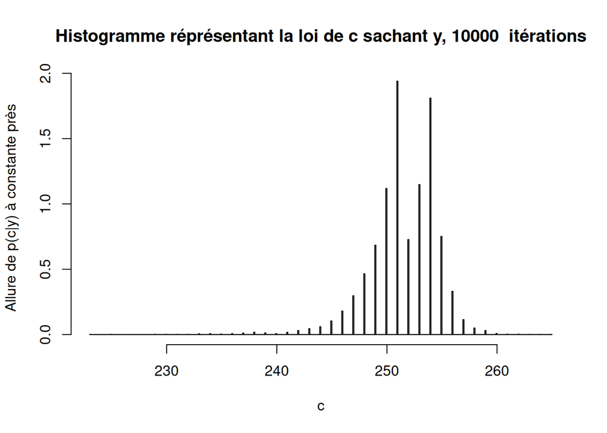

```
##                                       Donnée cherchée      Valeur
## 1                                 Point de changement 251.0000000
## 2 Borne inférieure de l'intervalle de confiance à 75% 248.0000000
## 3 Borne supérieure de l'intervalle de confiance à 75% 255.0000000
## 4                  Fréquence de 1 avant le changement   0.1960000
## 5                  Fréquence de 1 après le changement   0.9200000
## 6                                   Thêta 1 théorique   0.1666667
## 7                                   Thêta 2 théorique   0.9000000
## 8                       Point de changement théorique 251.0000000
```

```r
y_gauche <- rbinom(250, size = 1, prob = 1/6)
y_droite <- rbinom(250, size = 1, prob = 9/10)
y <- c(y_gauche,y_droite)
gibbs(y,10000,1/6,9/10,251)
```

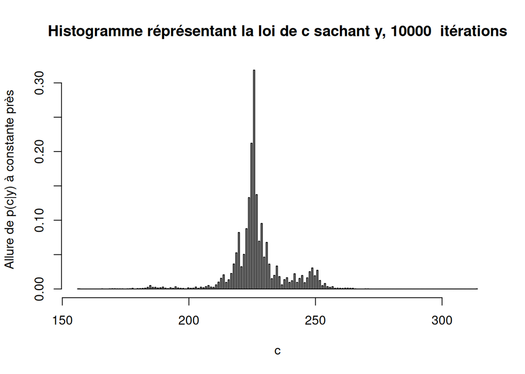

```
##                                       Donnée cherchée      Valeur
## 1                                 Point de changement 226.0000000
## 2 Borne inférieure de l'intervalle de confiance à 75% 220.0000000
## 3 Borne supérieure de l'intervalle de confiance à 75% 240.1250000
## 4                  Fréquence de 1 avant le changement   0.2177778
## 5                  Fréquence de 1 après le changement   0.6472727
## 6                                   Thêta 1 théorique   0.2500000
## 7                                   Thêta 2 théorique   0.6666667
## 8                       Point de changement théorique 251.0000000
```

```r
y_gauche <- rbinom(250, size = 1, prob = 1/4)
y_droite <- rbinom(250, size = 1, prob = 2/3)
y <- c(y_gauche,y_droite)
gibbs(y,10000,1/4,2/3,251)
```

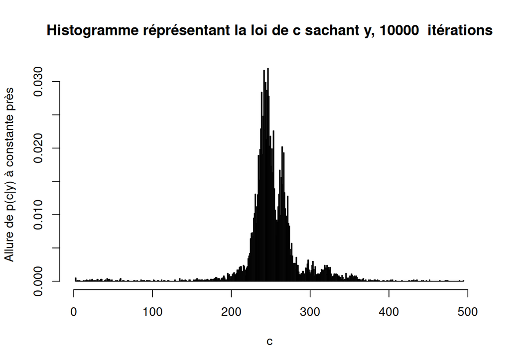

```
##                                       Donnée cherchée      Valeur
## 1                                 Point de changement 247.0000000
## 2 Borne inférieure de l'intervalle de confiance à 75% 231.0000000
## 3 Borne supérieure de l'intervalle de confiance à 75% 276.0000000
## 4                  Fréquence de 1 avant le changement   0.3699187
## 5                  Fréquence de 1 après le changement   0.5748031
## 6                                   Thêta 1 théorique   0.4444444
## 7                                   Thêta 2 théorique   0.5555556
## 8                       Point de changement théorique 251.0000000
```

```r
y_gauche <- rbinom(250, size = 1, prob = 4/9)
y_droite <- rbinom(250, size = 1, prob = 5/9)
y <- c(y_gauche,y_droite)
gibbs(y,10000,4/9,5/9,251)
```

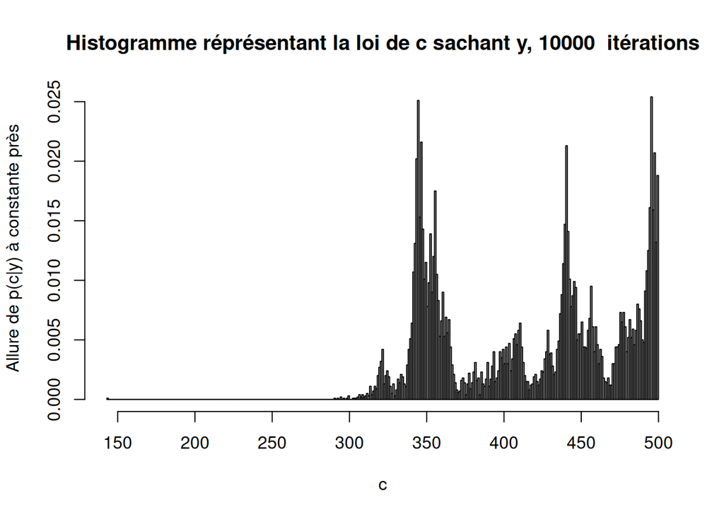

```
##                                       Donnée cherchée      Valeur
## 1                                 Point de changement 345.0000000
## 2 Borne inférieure de l'intervalle de confiance à 75% 345.0000000
## 3 Borne supérieure de l'intervalle de confiance à 75% 493.0000000
## 4                  Fréquence de 1 avant le changement   0.6773256
## 5                  Fréquence de 1 après le changement   0.5833333
## 6                                   Thêta 1 théorique   0.6666667
## 7                                   Thêta 2 théorique   0.6666667
## 8                       Point de changement théorique 251.0000000
```

```r
y_gauche <- rbinom(250, size = 1, prob = 2/3)
y_droite <- rbinom(250, size = 1, prob = 2/3)
y <- c(y_gauche,y_droite)
gibbs(y,10000,2/3,2/3,251)
```

## Pour des y tirés aléatoirements de petite taille (point de changement = 26)

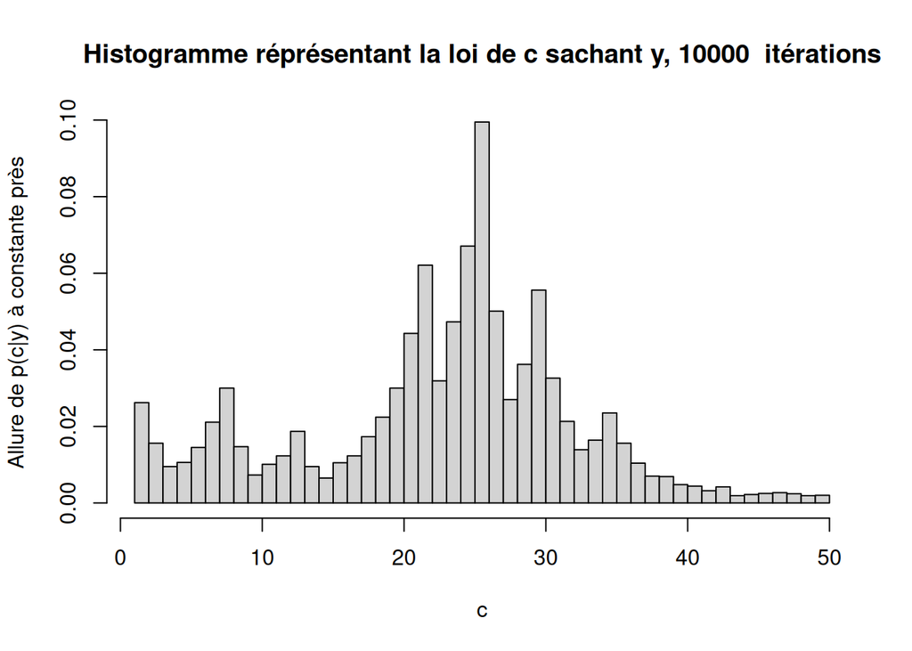

```
##                                       Donnée cherchée     Valeur
## 1                                 Point de changement 26.0000000
## 2 Borne inférieure de l'intervalle de confiance à 75%  8.0000000
## 3 Borne supérieure de l'intervalle de confiance à 75% 33.0000000
## 4                  Fréquence de 1 avant le changement  0.2400000
## 5                  Fréquence de 1 après le changement  0.7600000
## 6                                   Thêta 1 théorique  0.1666667
## 7                                   Thêta 2 théorique  0.9000000
## 8                       Point de changement théorique 26.0000000
```

```r
y_gauche <- rbinom(25, size = 1, prob = 1/6)
y_droite <- rbinom(25, size = 1, prob = 9/10)
y <- c(y_gauche,y_droite)
gibbs(y,10000,1/6,9/10,26)
```

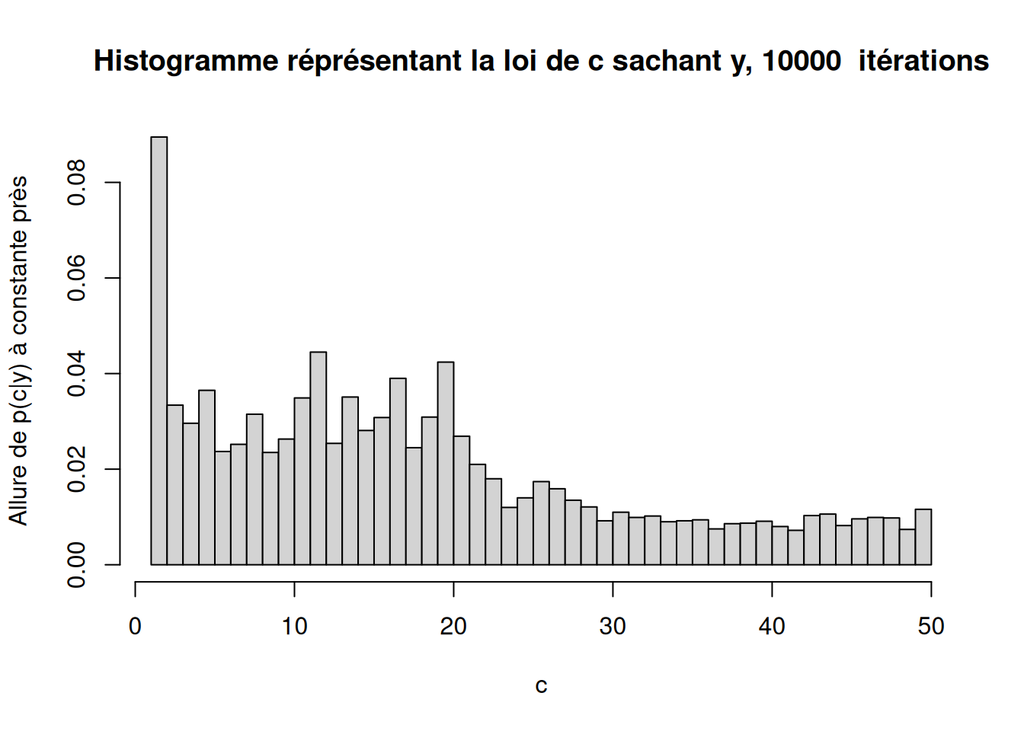

```
##                                       Donnée cherchée     Valeur
## 1                                 Point de changement 12.0000000
## 2 Borne inférieure de l'intervalle de confiance à 75%  4.0000000
## 3 Borne supérieure de l'intervalle de confiance à 75% 37.0000000
## 4                  Fréquence de 1 avant le changement  0.2727273
## 5                  Fréquence de 1 après le changement  0.6153846
## 6                                   Thêta 1 théorique  0.2500000
## 7                                   Thêta 2 théorique  0.6666667
## 8                       Point de changement théorique 26.0000000
```

```r
y_gauche <- rbinom(25, size = 1, prob = 1/4)
y_droite <- rbinom(25, size = 1, prob = 2/3)
y <- c(y_gauche,y_droite)
gibbs(y,10000,1/4,2/3,26)
```

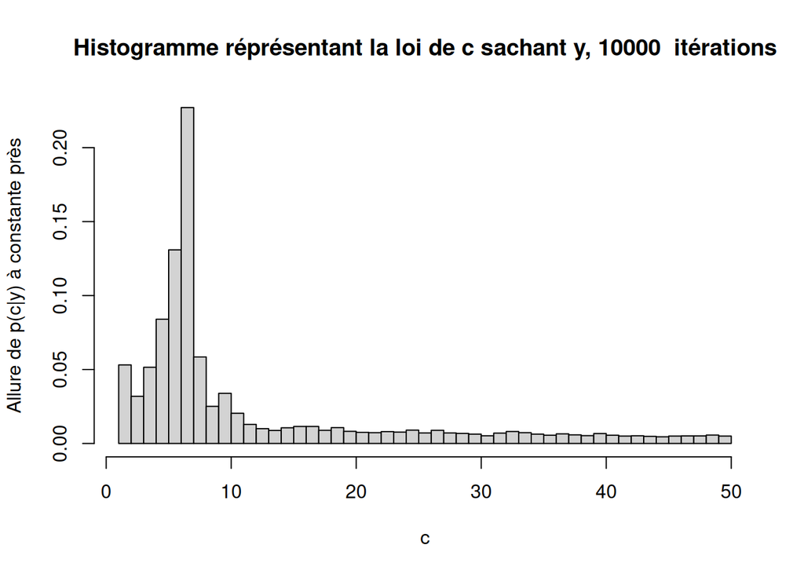

```
##                                       Donnée cherchée     Valeur
## 1                                 Point de changement  7.0000000
## 2 Borne inférieure de l'intervalle de confiance à 75%  4.0000000
## 3 Borne supérieure de l'intervalle de confiance à 75% 29.0000000
## 4                  Fréquence de 1 avant le changement  1.0000000
## 5                  Fréquence de 1 après le changement  0.3863636
## 6                                   Thêta 1 théorique  0.4444444
## 7                                   Thêta 2 théorique  0.5555556
## 8                       Point de changement théorique 26.0000000
```

```r
y_gauche <- rbinom(25, size = 1, prob = 4/9)
y_droite <- rbinom(25, size = 1, prob = 5/9)
y <- c(y_gauche,y_droite)
gibbs(y,10000,4/9,5/9,26)
```

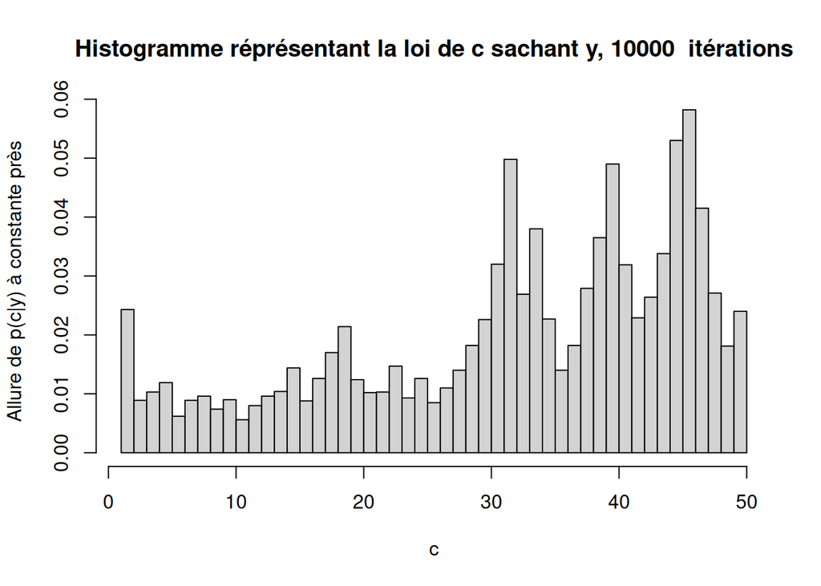

```
##                                       Donnée cherchée     Valeur
## 1                                 Point de changement 46.0000000
## 2 Borne inférieure de l'intervalle de confiance à 75% 14.0000000
## 3 Borne supérieure de l'intervalle de confiance à 75% 46.0000000
## 4                  Fréquence de 1 avant le changement  0.6888889
## 5                  Fréquence de 1 après le changement  0.4000000
## 6                                   Thêta 1 théorique  0.6666667
## 7                                   Thêta 2 théorique  0.6666667
## 8                       Point de changement théorique 26.0000000
```

```r
y_gauche <- rbinom(25, size = 1, prob = 2/3)
y_droite <- rbinom(25, size = 1, prob = 2/3)
y <- c(y_gauche,y_droite)
gibbs(y,10000,2/3,2/3,26)
```

## Pour un même y, on essaie différents thêta 1 et thêta 2 initiaux

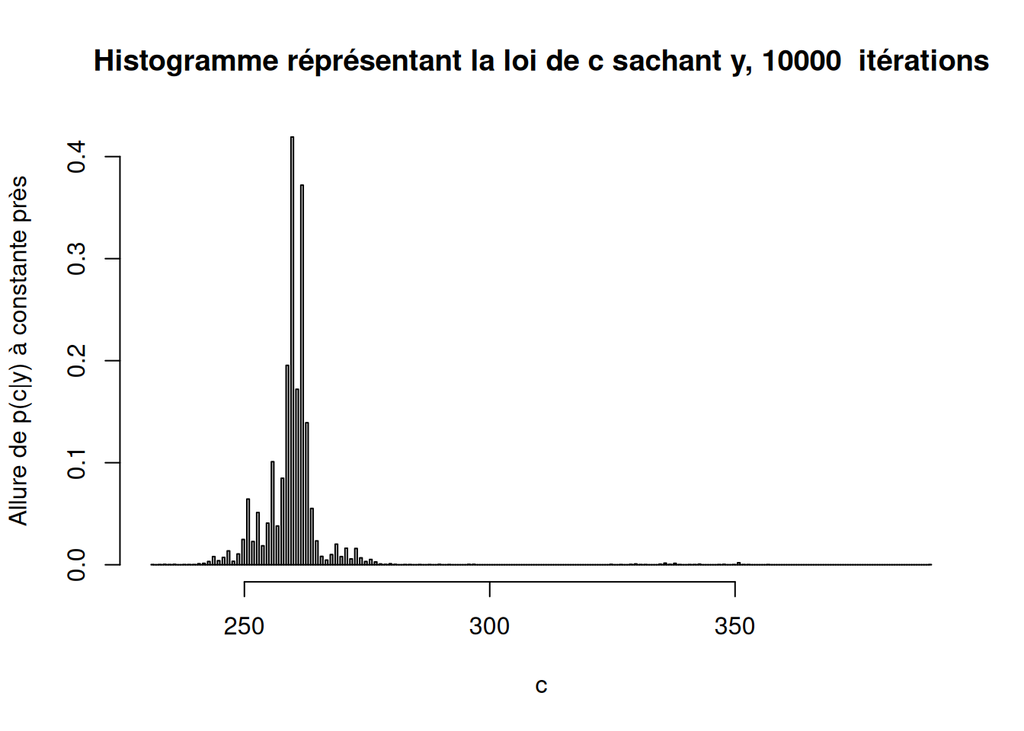

```
##                                        Donnée cherchée      Valeur
## 1                                  Point de changement 260.0000000
## 2  Borne inférieure de l'intervalle de confiance à 75% 255.0000000
## 3  Borne supérieure de l'intervalle de confiance à 75% 263.0000000
## 4                   Fréquence de 1 avant le changement   0.2586873
## 5                   Fréquence de 1 après le changement   0.6016598
## 6                                    Thêta 1 théorique   0.2500000
## 7                                    Thêta 2 théorique   0.6666667
## 8                        Point de changement théorique 251.0000000
## 9                    Thêta 1 initial pour l'algorithme   0.2500000
## 10                   Thêta 2 initial pour l'algorithme   0.6666667
```

```r
y_gauche <- rbinom(250, size = 1, prob = 1/4)
y_droite <- rbinom(250, size = 1, prob = 2/3)
y <- c(y_gauche,y_droite)

gibbs(y,10000,1/4,2/3,251, 1/4,2/3)
```

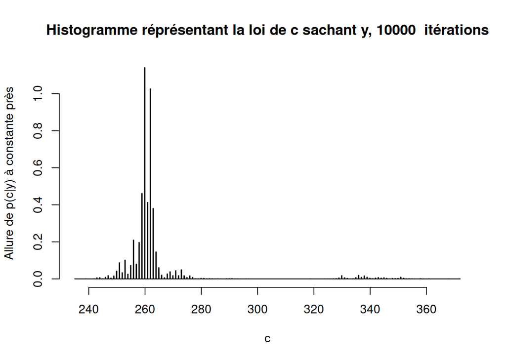

```
##                                        Donnée cherchée      Valeur
## 1                                  Point de changement 260.0000000
## 2  Borne inférieure de l'intervalle de confiance à 75% 256.0000000
## 3  Borne supérieure de l'intervalle de confiance à 75% 264.0000000
## 4                   Fréquence de 1 avant le changement   0.2586873
## 5                   Fréquence de 1 après le changement   0.6016598
## 6                                    Thêta 1 théorique   0.2500000
## 7                                    Thêta 2 théorique   0.6666667
## 8                        Point de changement théorique 251.0000000
## 9                    Thêta 1 initial pour l'algorithme   0.2000000
## 10                   Thêta 2 initial pour l'algorithme   0.7000000
```

```r
gibbs(y,10000,1/4,2/3,251, 0.2,0.7)
```

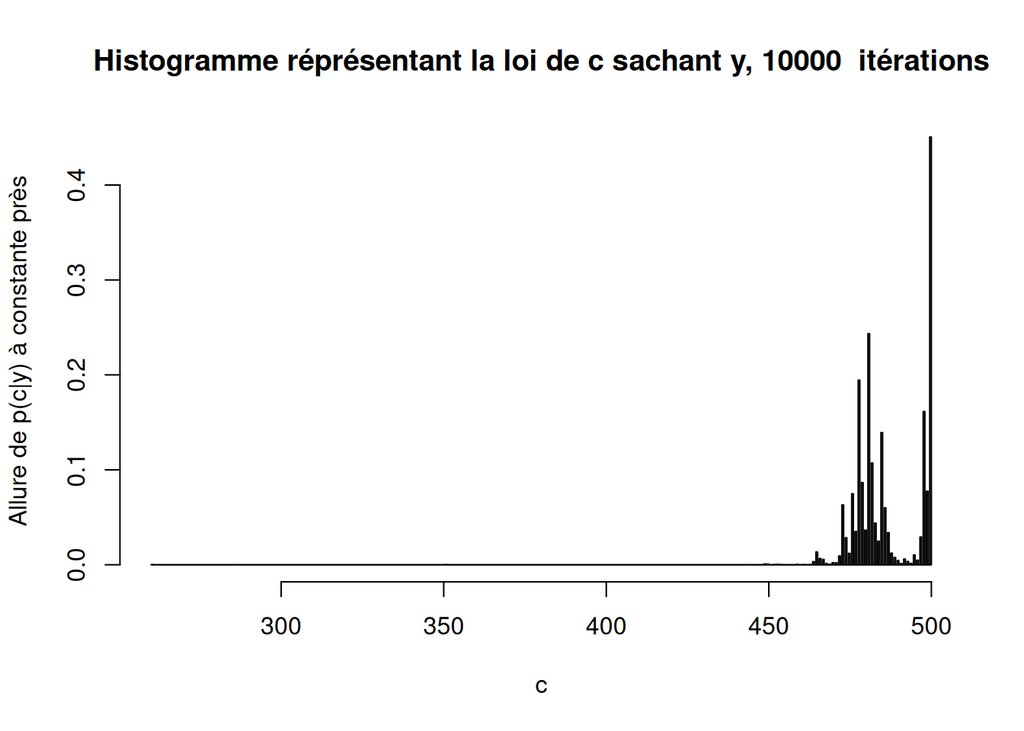

```
##                                        Donnée cherchée      Valeur
## 1                                  Point de changement 500.0000000
## 2  Borne inférieure de l'intervalle de confiance à 75% 477.0000000
## 3  Borne supérieure de l'intervalle de confiance à 75% 500.0000000
## 4                   Fréquence de 1 avant le changement   0.4228457
## 5                   Fréquence de 1 après le changement   1.0000000
## 6                                    Thêta 1 théorique   0.2500000
## 7                                    Thêta 2 théorique   0.6666667
## 8                        Point de changement théorique 251.0000000
## 9                    Thêta 1 initial pour l'algorithme   0.1000000
## 10                   Thêta 2 initial pour l'algorithme   0.9000000
```

```r
gibbs(y,10000,1/4,2/3,251, 0.1,0.9)
```

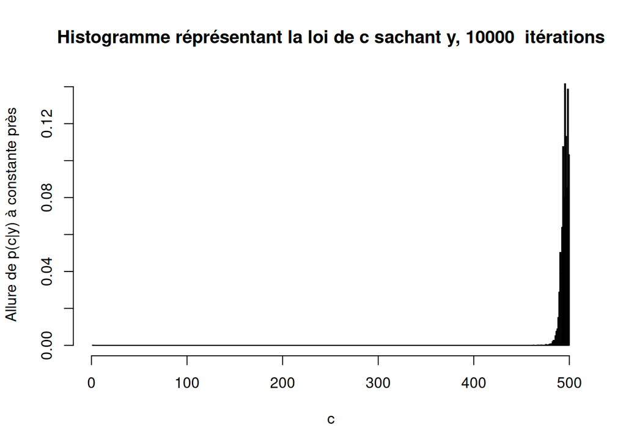

```
##                                        Donnée cherchée      Valeur
## 1                                  Point de changement 496.0000000
## 2  Borne inférieure de l'intervalle de confiance à 75% 491.0000000
## 3  Borne supérieure de l'intervalle de confiance à 75% 499.0000000
## 4                   Fréquence de 1 avant le changement   0.4242424
## 5                   Fréquence de 1 après le changement   0.4000000
## 6                                    Thêta 1 théorique   0.2500000
## 7                                    Thêta 2 théorique   0.6666667
## 8                        Point de changement théorique 251.0000000
## 9                    Thêta 1 initial pour l'algorithme   0.6666667
## 10                   Thêta 2 initial pour l'algorithme   0.2500000
```

```r
gibbs(y,10000,1/4,2/3,251, 2/3, 1/4)
```

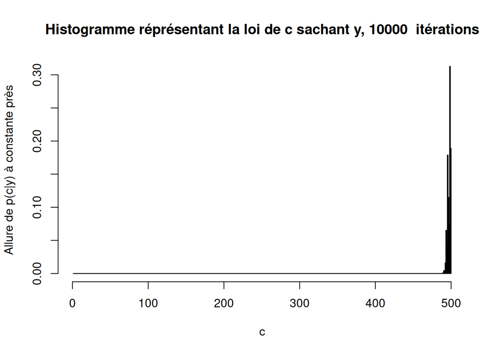

```
##                                        Donnée cherchée      Valeur
## 1                                  Point de changement 499.0000000
## 2  Borne inférieure de l'intervalle de confiance à 75% 495.0000000
## 3  Borne supérieure de l'intervalle de confiance à 75% 500.0000000
## 4                   Fréquence de 1 avant le changement   0.4236948
## 5                   Fréquence de 1 après le changement   0.5000000
## 6                                    Thêta 1 théorique   0.2500000
## 7                                    Thêta 2 théorique   0.6666667
## 8                        Point de changement théorique 251.0000000
## 9                    Thêta 1 initial pour l'algorithme   0.9000000
## 10                   Thêta 2 initial pour l'algorithme   0.1000000
```

```r
gibbs(y,10000,1/4,2/3,251, 0.9,0.1)
```

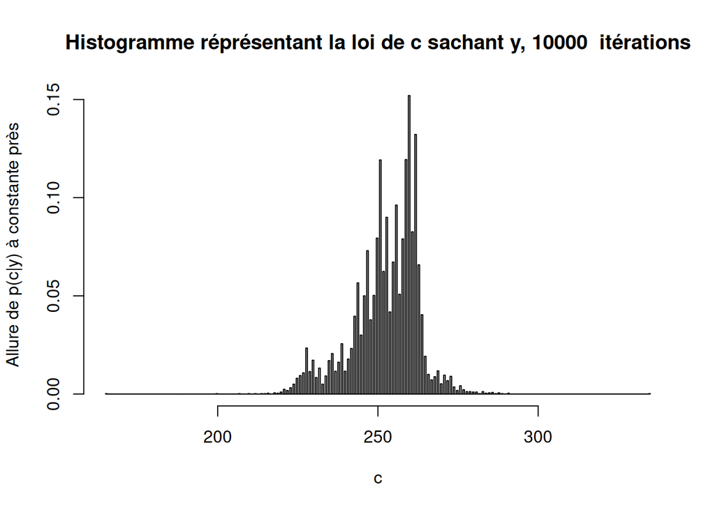

```
##                                        Donnée cherchée      Valeur
## 1                                  Point de changement 260.0000000
## 2  Borne inférieure de l'intervalle de confiance à 75% 241.0000000
## 3  Borne supérieure de l'intervalle de confiance à 75% 262.0000000
## 4                   Fréquence de 1 avant le changement   0.2586873
## 5                   Fréquence de 1 après le changement   0.6016598
## 6                                    Thêta 1 théorique   0.2500000
## 7                                    Thêta 2 théorique   0.6666667
## 8                        Point de changement théorique 251.0000000
## 9                    Thêta 1 initial pour l'algorithme   0.5000000
## 10                   Thêta 2 initial pour l'algorithme   0.5000000
```

```r
gibbs(y,10000,1/4,2/3,251,1/2,1/2)
```

On remarque que plus la taille du signal initial $y$ est grande, plus la fréquence calculée avant et après le changement est précise. De plus, l’algorithme trouve mieux le point de changement (avec un nombre d’itérations de l’algorithme de 10.000). Ce qui se comprend, étant donné qu’on a plus d’informations sur les signaux émis à fréquence $\theta_1$ et à fréquence $\theta_2$. La convergence de l’algorithme est un peu plus discutable lorsque la taille de la chaine diminue.

De plus, si le nombre d’itérations venait à baisser, on constaterait également ces phénomènes d’imprécisions.

Ajoutons à cela que si les fréquences $\theta_1$ et $\theta_2$ sont très proches, il est difficile pour l’algorithme de trouver un point de changement, ce qui est tout à fait normal car il semble que le signal en entier est émis à la même fréquence.

Enfin, on remarque qu’en changeant les valeurs initiales de $\theta_1$ et $\theta_2$ il y a plusieurs changements, et parfois il arrive de ne pas du tout converger vers le point de changement. Lorsque $\theta_1,theorique$ < $\theta_2,theorique$, l’algorithme a des difficultés à converger lorsque $\theta_1,initial$ > $\theta_2,initial$ (et inversement).

De plus, la difficulté à converger est d’autant plus grande lorsque les $\theta_i$ initiaux se rapprochent des valeurs limites 0 et 1.

La convergence est bien meilleure lorsque les $\theta_i$ respectifs initiaux sont proches des valeurs théoriques et respectent l’odre des $\theta_i$ théoriques.

## Question 7

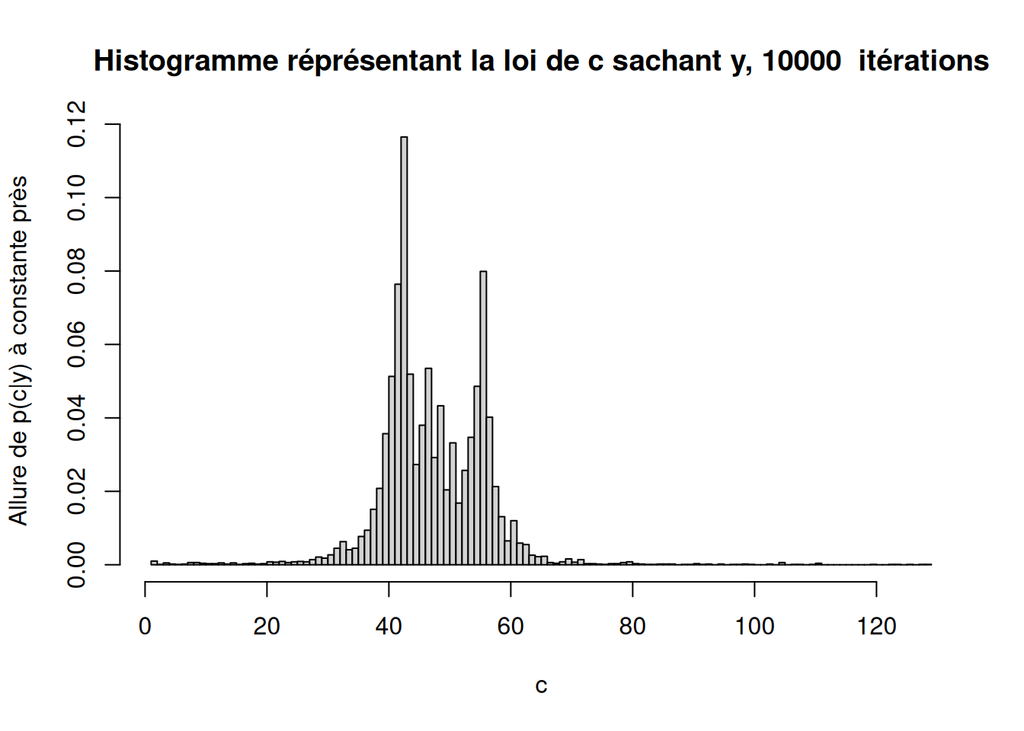

```
##                                       Donnée cherchée     Valeur
## 1                                 Point de changement 43.0000000
## 2 Borne inférieure de l'intervalle de confiance à 75% 40.0000000
## 3 Borne supérieure de l'intervalle de confiance à 75% 56.0000000
## 4                  Fréquence de 1 avant le changement  0.2142857
## 5                  Fréquence de 1 après le changement  0.6136364
```

```r
y= scan("TP2_sequence_1.txt")
gibbs(y,10000)
```

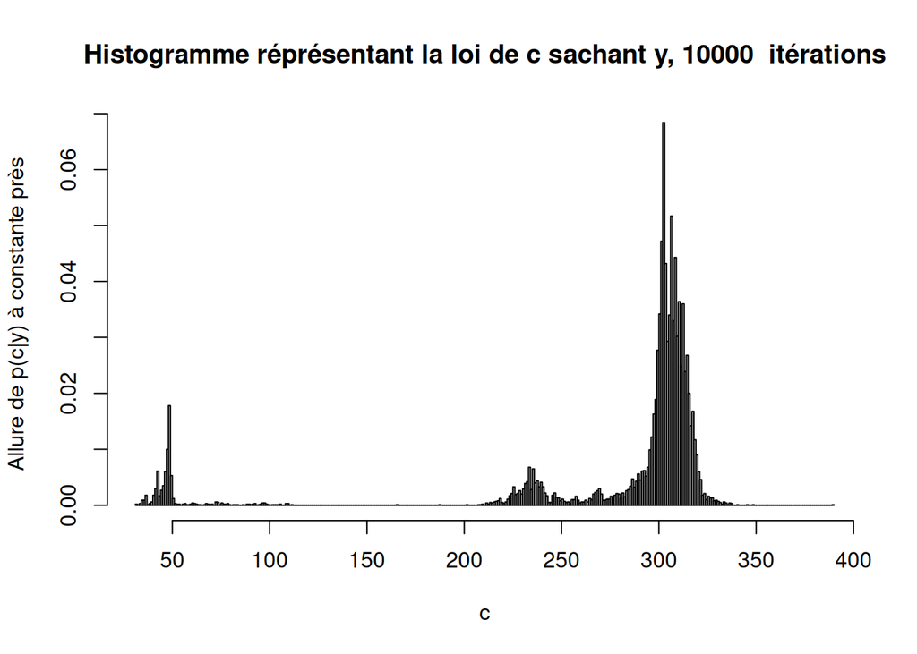

```
##                                       Donnée cherchée      Valeur
## 1                                 Point de changement 303.0000000
## 2 Borne inférieure de l'intervalle de confiance à 75% 236.0000000
## 3 Borne supérieure de l'intervalle de confiance à 75% 314.0000000
## 4                  Fréquence de 1 avant le changement   0.3245033
## 5                  Fréquence de 1 après le changement   0.8247423
```

```r
y = scan("TP2_sequence_2.txt")
gibbs(y,10000)
```

Après plusieurs exécutions, l’algorithme envoie en boucle un point de changement à l’indice 43 pour le premier jeu de données et à l’indice 303 pour le second jeu. Cependant, on peut constater quelques variations sur l’intervalle de confiance.

Pour le premier jeu, l’intervalle de confiance varie très peu sur plusieurs exécutions de l’algorithme, cependant, on remarque une plus grande variation des bornes inférieures et supérieures pour le second jeu de l’ordre de 5 unités en moyenne.

Pour le second jeu, on observe un pic principal aux alentours de l’indice 303 et un pic secondaire aux alentours de l’indice 49. De plus, Visuellement, quand on regarde le second jeu, il semble y avoir (au moins) 2 changements (à l’indice 49 et 335). Il y a plus d’émission après le deuxième changement qu’avant le premier changement, on peut alors émettre l’hypothèse que l’algorithme va converger vers une valeur plus proche du deuxième changement qui est plus “lourd”.